# 全球抗“疫”：用Python带你了解世界疫情

王梦圆

2020-02

# 1 数据的读取及处理

本次使用的数据是Github上一个项目里的，也可以直接用pandas包导入，需要注意的是不能直接使用Github那个网址，否则会报错，需要将前面部分改成https://raw.githubusercontent.com/，然后就是加入数据的目录地址。数据主要是是三个文件，包含了疫情的确诊数（confirmed），治愈数（recoved），死亡数（deaths）。confirmed表里面包含发生疫情的国家，经纬度，以及从2020年1月22日至今的每日的确诊数；recovered表则记录了治愈数；deaths表则记录了死亡数。

```python
import numpy as np
import pandas as pd
#confirmed = pd.read_csv('https://raw.githubusercontent.com/CSSEGISandData/COVID-19/master/csse_covid_19_data/csse_covid_19_time_series/time_series_19-covid-Confirmed.csv')
#recovered = pd.read_csv('https://raw.githubusercontent.com/CSSEGISandData/COVID-19/master/csse_covid_19_data/csse_covid_19_time_series/time_series_19-covid-Recovered.csv')
#deaths =pd.read_csv('https://raw.githubusercontent.com/CSSEGISandData/COVID-19/master/csse_covid_19_data/csse_covid_19_time_series/time_series_19-covid-Deaths.csv')
confirmed = pd.read_csv('./time_series_19-covid-Confirmed.csv')
recovered = pd.read_csv('./time_series_19-covid-Recovered.csv')
deaths = pd.read_csv('./time_series_19-covid-Deaths.csv')
```

数据已经导入了，让我们来看看数据是啥样的吧。head(5)是查看数据前五行；confirmed表里面包含发生疫情的国家，经纬度，以及从2020年1月22日至今的每日的确诊数；recovered表则记录了治愈数；deaths表则记录了死亡数。

```python
confirmed.head(5)
```

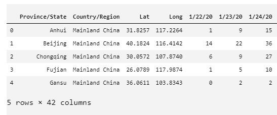

表1

```python
recovered.head(5)
```

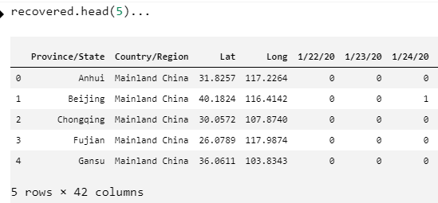

表2

```python
deaths.head(5)
```

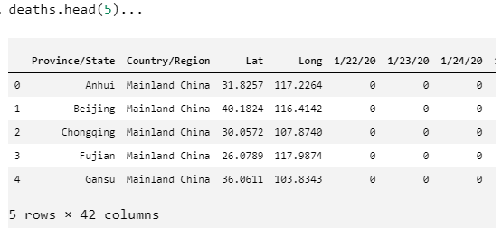

表3

```python
print(confirmed.shape)
```

[output not shown]

```python
print(recovered.shape)
```

[output not shown]

```python
print(deaths.shape)
```

[output not shown]